# Bayesian Classification Project Report

YICHEN_LI

# 1.Synopsis

In today’s social media and online platforms, sentiment analysis has become an important tool for understanding user feedback and emotions. The aim of this project is to develop a sentiment classification model based on a plain Bayesian classifier that can accurately predict sentiment categories from text data. The Emotion Dataset from Kaggle is used as the data source, which contains three emotion labels, angers,fear,joy.An efficient and accurate sentiment classification system is constructed by preprocessing, feature engineering and model training of text data.

# 2.Methodology

## 2.1 Data loading and exploration

### 2.1.1 Data loading

Load the dataset and perform initial exploration to understand the basic structure and distribution of the data.

```r
options(warn = -1)
required_packages <- c("tidyverse", "readr", "tm", "SnowballC", "textstem",
                       "tokenizers", "caTools", "e1071", "caret", "naivebayes", "ggplot2")
installed_packages <- rownames(installed.packages())

# Check and install missing packages
for(pkg in required_packages){
  if(!(pkg %in% installed_packages)){
    install.packages(pkg, dependencies = TRUE)
  }
}

# Load the libraries
suppressMessages(library(tidyverse))
suppressMessages(library(readr))
suppressMessages(library(tm))
suppressMessages(library(SnowballC))
suppressMessages(library(textstem))
suppressMessages(library(tokenizers))
suppressMessages(library(caTools))
suppressMessages(library(e1071))
suppressMessages(library(caret))
suppressMessages(library(naivebayes))
suppressMessages(library(ggplot2))
```

```r
# Load the data
emotion_data <- read_csv("/Users/lyly/R_project_DSIA_YICHEN_LI/mprojet_datas/Emotion_classify_Data.csv", show_col_types = FALSE)

# View data structure
glimpse(emotion_data)
```

```
## Rows: 5,937
## Columns: 2
## $ Comment <chr> "i seriously hate one subject to death but now i feel reluctan…
## $ Emotion <chr> "fear", "anger", "fear", "joy", "fear", "anger", "anger", "ang…
```

```r
# Confirm column names
print(names(emotion_data))
```

```
## [1] "Comment" "Emotion"
```

Dataset with two fields: Comment: A column of textual content, e.g. “I seriously hate one subject to death but no…” Emotion: Sentiment categorical columns, such as “fear”, “anger”, “joy”. There are a total of 5,937 rows in the dataset, representing 5,937 comments and their corresponding sentiment classifications

### 2.1.2 Exploratory Data Analysis

Understand the basics of the data, including category distribution, text lengths

[output not shown]

The distribution of sentiment classifications is as follows:

anger: 2000 sets fear: 1937 sets joy: 2000 sets

```r
# Calculate the text length
emotion_data <- emotion_data %>%
  mutate(text_length = nchar(Comment))

# View statistics on text length
summary(emotion_data$text_length)
```

```
##    Min. 1st Qu.  Median    Mean 3rd Qu.    Max.
##    9.00   54.00   86.00   97.43  130.00  298.00
```

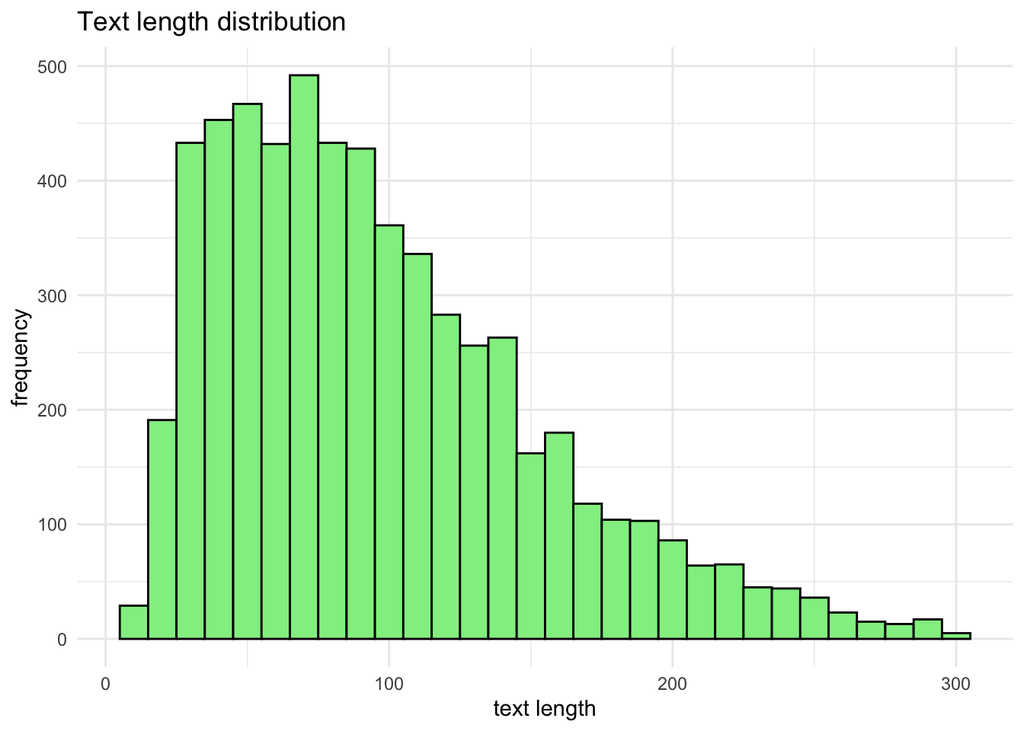

```r
# Visualize the text length distribution
ggplot(emotion_data, aes(x = text_length)) +
  geom_histogram(binwidth = 10, fill = "lightgreen", color = "black") +
  theme_minimal() +
  labs(title = "Text length distribution", x = "text length", y = "frequency")
```

From the histogram,can see the distribution of text lengths:

1. The text length range is roughly between 0 and 300, and the text length is shorter (within 100) to occupy a large proportion.
2. The frequency of text in the range of 50 to 100 is the highest, and the frequency of each length segment is about 400 to 500. The number of texts with a length greater than 100 gradually decreases, showing a typical right-skewed distribution (long-tail distribution).
3. A small amount of text is large in length (greater than 200 or even close to 300), but the amount of these data is relatively small.

## 2.2 Data preprocessing

### 2.2.1 Text cleaning

Preprocess text data to create a corpus and clean it up for noise, including case differences, punctuation, numbers, stop words, and extra spaces. With these steps, the text is standardized into a clean format.

```r
# Create a text corpus
corpus <- VCorpus(VectorSource(emotion_data$Comment))

# Text preprocessing functions
clean_corpus <- function(corpus) {
  corpus <- tm_map(corpus, content_transformer(tolower)) # convert to lowercase
  corpus <- tm_map(corpus, removePunctuation) # remove punctuation
  corpus <- tm_map(corpus, removeNumbers) # remove numbers
  corpus <- tm_map(corpus, removeWords, stopwords("en"))
# remove stopwords
  corpus <- tm_map(corpus, stripWhitespace) # remove extra spaces
  return(corpus)
}

# Clean the corpus
corpus_clean <- clean_corpus(corpus)
```

### 2.2.2 Segmentation, Stemming and Morphological Reduction

Stemming and morphology reduction with the textstem package

The text is further simplified by stemming and lemmatological reduction, which reduces the word to its root form, while the word form also restores it to its base form based on the grammatical and semantic context of the word. The combination of the two can reduce text redundancy and improve the processing efficiency of the model, while preserving the semantic information of the text.

```r
# Stem extraction
corpus_clean <- tm_map(corpus_clean, stemDocument)

# Morphology reduction
corpus_clean <- tm_map(corpus_clean, content_transformer(lemmatize_strings))
```

### 2.2.3 Text vectorization (TF-IDF)

A document-word matrix was created (weighted using TF-IDF), sparse words were removed, and finally the matrix was converted into a data frame and sentiment labels were added, completing the numerical processing from text to features

```r
# Create a document-word matrix
dtm <- DocumentTermMatrix(corpus_clean, control = list(weighting = weightTfIdf))

# Remove sparse terms
dtm_sparse <- removeSparseTerms(dtm, 0.99)

# Convert to data frame
data_features <- as.data.frame(as.matrix(dtm_sparse))

# Add emotion labels
data_features$Emotion <- emotion_data$Emotion
```

## 2.3 Training a Bayesian model

### 2.3.1 Split the dataset

Divide the dataset into training and testing sets (80% training, 20% testing)

```r
set.seed(123)

split <- sample.split(data_features$Emotion, SplitRatio = 0.8)
training_set <- subset(data_features, split == TRUE)
testing_set <- subset(data_features, split == FALSE)
```

### 2.3.2 Training a Simple Bayesian Classifier

Using the e1071 package

Based on the training dataset, a sentiment classification model was trained using the naïve Bayesian method, and the goal was to predict the sentiment category of the text by features. The advantage of the naïve Bayes model is that it is computationally efficient and suitable for processing high-dimensional data.

```r
# Training models
nb_model <- naiveBayes(Emotion ~ ., data = training_set)
```

### 2.3.3 Model prediction

Predictions on the test set

```r
# Make predictions
predictions <- predict(nb_model, newdata = testing_set)

# View the first few predictions
head(predictions)
```

```
## [1] joy  fear joy  joy  joy  joy
## Levels: anger fear joy
```

The test data were predicted by mood classification, and the first few prediction results were factorial variables, including the sentiment classification “anger”, “fear” and “joy”

## 2.4 Model evaluation

### 2.4.1 Calculate evaluation metrics

Accuracy, Precision, Recall, and F1 Score

```r
# Confusion matrix
# Determine levels for all emotion categories
emotion_levels <- levels(factor(emotion_data$Emotion))

# Convert the emotion labels of the testing set to factors and set the same levels
testing_set$Emotion <- factor(testing_set$Emotion, levels = emotion_levels)

# Convert predictions to factors and set the same levels
predictions <- factor(predictions, levels = emotion_levels)

# Verify that the factor levels are the same
print(emotion_levels)
```

```
## [1] "anger" "fear"  "joy"
```

```r
print(levels(testing_set$Emotion))
```

```
## [1] "anger" "fear"  "joy"
```

```r
print(levels(predictions))
```

```
## [1] "anger" "fear"  "joy"
```

```r
# Generate the confusion matrix
conf_mat <- confusionMatrix(predictions, testing_set$Emotion)
print(conf_mat)
```

```
## Confusion Matrix and Statistics
##
##           Reference
## Prediction anger fear joy
##      anger   106   68  35
##      fear     28   83  15
##      joy     266  236 350
##
## Overall Statistics
##
##                Accuracy : 0.4541
##                  95% CI : (0.4255, 0.4829)
##     No Information Rate : 0.337
##     P-Value [Acc > NIR] : < 2.2e-16
##
##                   Kappa : 0.1781
##
##  Mcnemar's Test P-Value : < 2.2e-16
##
## Statistics by Class:
##
##                      Class: anger Class: fear Class: joy
## Sensitivity                0.2650     0.21447     0.8750
## Specificity                0.8691     0.94625     0.3621
## Pos Pred Value             0.5072     0.65873     0.4108
## Neg Pred Value             0.6994     0.71348     0.8507
## Prevalence                 0.3370     0.32603     0.3370
## Detection Rate             0.0893     0.06992     0.2949
## Detection Prevalence       0.1761     0.10615     0.7178
## Balanced Accuracy          0.5671     0.58036     0.6186
```

```r
# Extract evaluation metrics
accuracy <- conf_mat$overall['Accuracy']
precision <- conf_mat$byClass[,'Precision']
recall <- conf_mat$byClass[,'Recall']
f1 <- conf_mat$byClass[,'F1']

# Print the evaluation metrics
print(paste("Accuracy:", round(accuracy, 4)))
```

```
## [1] "Accuracy: 0.4541"
```

```r
print("Precision per class:")
```

```
## [1] "Precision per class:"
```

```r
print(precision)
```

```
## Class: anger  Class: fear   Class: joy
##    0.5071770    0.6587302    0.4107981
```

```r
print("Recall per category:")
```

```
## [1] "Recall per category:"
```

```r
print(recall)
```

```
## Class: anger  Class: fear   Class: joy
##    0.2650000    0.2144703    0.8750000
```

```r
print("F1 score per category:")
```

```
## [1] "F1 score per category:"
```

```r
print(f1)
```

```
## Class: anger  Class: fear   Class: joy
##    0.3481117    0.3235867    0.5591054
```

Prediction and evaluation results of Bayesian classification models. The overall accuracy was 45.41%, indicating that the classification effect of the model was limited. Among them, for the category “joy”, the performance is relatively good, with a recall rate of 87.5%, but the precision rate is only 41.08%, indicating that the model can identify “joy” well, but there are many samples that are misjudged as “joy”. On the two categories of “anger” and “fear”, the recall rates were 26.5% and 21.4%, respectively, and the model had significant missing errors in these categories, and the overall classification performance was poor.

Bayesian models may be limited by feature independence assumptions and biases in data distribution, resulting in uneven classification performance. In particular, the classification effect of “anger” and “fear” is poor, with F1 scores of only 0.348 and 0.324, indicating that the model is not able to distinguish between these categories.

### 2.4.2 Visual confusion matrix

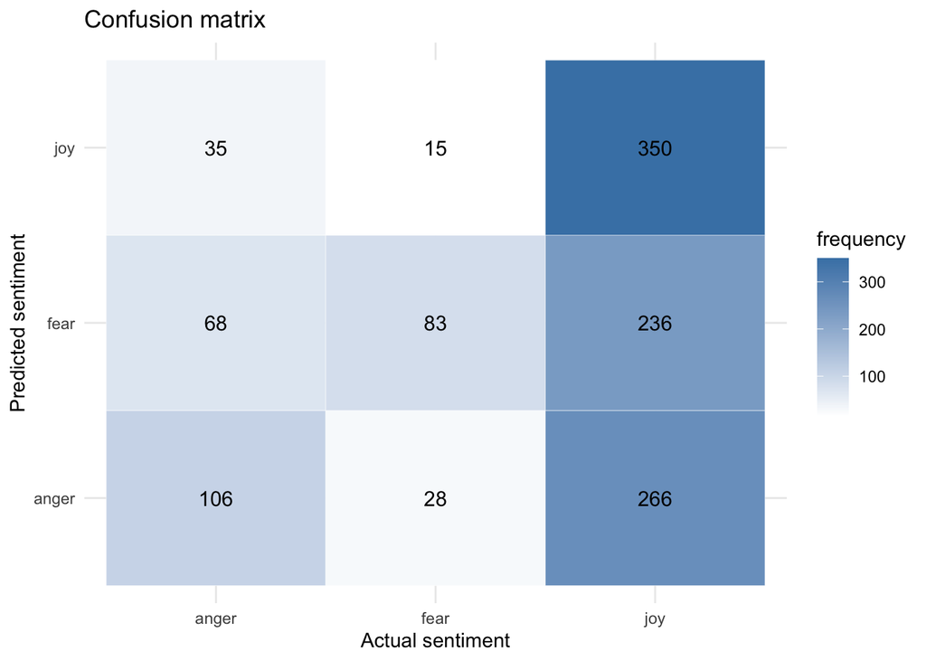

```r
# Convert confusion matrix to data frame
conf_mat_df <- as.data.frame(conf_mat$table)
colnames(conf_mat_df) <- c("actual sentiment", "predicted sentiment", "frequency")

# Plot the heatmap
ggplot(data = conf_mat_df, aes(x = `actual sentiment`, y = `predicted sentiment`, fill = frequency)) +
  geom_tile(color = "white") +
  scale_fill_gradient(low = "white", high = "steelblue") +
  theme_minimal() +
  labs(title = "Confusion matrix", x = "Actual sentiment", y = "Predicted sentiment") +
  geom_text(aes(label = `frequency`), color = "black", size = 4)
```

# 3. Optimizations

Using Random Forest models to optimize and improve the performance of sentiment classification. Random Forest is an integrated learning method that can effectively handle high-dimensional data and complex classification tasks by constructing multiple decision trees and combining their predictions.

```r
required_packages <- c("randomForest","dplyr")
installed_packages <- rownames(installed.packages())
for(pkg in required_packages){
  if(!(pkg %in% installed_packages)){
    install.packages(pkg, dependencies = TRUE)
  }
}


suppressMessages(library(randomForest))
suppressMessages(library(dplyr))
```

## 3.1 Training the Random Forest Model

Using the same training and test sets as the Naive Bayes, the random forest model is trained and its performance evaluated.

```r
# Convert Emotion to factor in training and testing sets
training_set$Emotion <- as.factor(training_set$Emotion)
testing_set$Emotion <- as.factor(testing_set$Emotion)

# Check the distribution of classes in the training set
table(training_set$Emotion)
```

```
##
## anger  fear   joy
##  1600  1550  1600
```

```r
# Train the Random Forest model
rf_model <- randomForest(Emotion ~ .,
                         data = training_set,
                         importance = TRUE,
                         ntree = 500)
```

## 3.2 Model Evaluation

Evaluate metrics such as accuracy, precision, recall, and F1 score for random forest models are calculated

```r
# Make predictions on the test set
predictions_rf <- predict(rf_model, newdata = testing_set)

# Ensure factor levels are consistent
emotion_levels_rf <- levels(factor(data_features$Emotion))
testing_set$Emotion <- factor(testing_set$Emotion, levels = emotion_levels_rf)
predictions_rf <- factor(predictions_rf, levels = emotion_levels_rf)

# confusion matrix
conf_mat_rf <- confusionMatrix(predictions_rf, testing_set$Emotion)

# Extract evaluation metrics
accuracy_rf <- conf_mat_rf$overall['Accuracy']
precision_rf <- conf_mat_rf$byClass[,'Precision']
recall_rf <- conf_mat_rf$byClass[,'Recall']
f1_rf <- conf_mat_rf$byClass[,'F1']

# Evaluation metrics
print(paste("Random Forest Accuracy:", round(accuracy_rf, 4)))
```

```
## [1] "Random Forest Accuracy: 0.6209"
```

```r
print("Random Forest Precision per class:")
```

```
## [1] "Random Forest Precision per class:"
```

```r
print(precision_rf)
```

```
## Class: anger  Class: fear   Class: joy
##    0.6343750    0.7600000    0.5396825
```

```r
print("Random Forest Recall per class:")
```

```
## [1] "Random Forest Recall per class:"
```

```r
print(recall_rf)
```

```
## Class: anger  Class: fear   Class: joy
##    0.5075000    0.5891473    0.7650000
```

```r
print("Random Forest F1 Score per class:")
```

```
## [1] "Random Forest F1 Score per class:"
```

```r
print(f1_rf)
```

```
## Class: anger  Class: fear   Class: joy
##    0.5638889    0.6637555    0.6328852
```

## 3.3 Cross-validation (Bayesian model)

Evaluate the robustness of the model using k-fold cross-validation

```r
# Set the cross-validation parameters
train_control <- trainControl(method = "cv", number = 10)

# Use cross-validation to train the model
nb_cv <- train(Emotion ~ ., data = data_features, method = "naive_bayes", trControl = train_control)

# Check the cross-validation results
print(nb_cv)
```

```
## Naive Bayes
##
## 5937 samples
##  145 predictor
##    3 classes: 'anger', 'fear', 'joy'
##
## No pre-processing
## Resampling: Cross-Validated (10 fold)
## Summary of sample sizes: 5343, 5343, 5344, 5344, 5343, 5343, ...
## Resampling results across tuning parameters:
##
##   usekernel  Accuracy   Kappa
##   FALSE      0.4601646  0.18713639
##    TRUE      0.4003728  0.09724326
##
## Tuning parameter 'laplace' was held constant at a value of 0
## Tuning
##  parameter 'adjust' was held constant at a value of 1
## Accuracy was used to select the optimal model using the largest value.
## The final values used for the model were laplace = 0, usekernel = FALSE
##  and adjust = 1.
```

The best parameter of the Naive Bayes model in the 10-fold cross-validation is usekernel = FALSE, the accuracy is 46.02%, and the Kappa value is only 0.1871, indicating that the performance of the model for sentiment classification is relatively average, and the classification consistency is low. Although the performance is slightly better without kernel density estimation, the overall accuracy and consistency are low, which may be due to the obvious limitations of the naïve Bayes model for tasks with complex category distributions

# 4. Results

## 4.2 Challenge Analysis

1. Feature independence assumption: The naïve Bayes model assumes that features are independent, which is often difficult to satisfy in text data, because words in text tend to have strong correlations (e.g., “hate” and “fear” often appear together).
2. Insufficient feature expression: Text features only use basic word frequency or TF-IDF methods, which may fail to fully capture the deep semantic features of emotions (such as syntactic relationships and contextual information).
3. Model simplicity: The naïve Bayesian model is suitable for handling linear and simple tasks, and may not perform well for complex multi-class text classification problems.

# 5.Conclusion and future work

## 5.2 Suggestions for improvement

1. Improve feature extraction. Use word embeddings such as Word2Vec, GloVe, or BERT instead of TF-IDF methods to capture the semantic and contextual information of words. Introduce sentiment dictionaries or sentiment analysis tools to enhance the model’s perception of emotion-related words.
2. Optimize model selection. Use more complex models such as support vector machines (SVMs), gradient boosting decision trees (e.g., XGBoost), or deep learning models (e.g., LSTM, BERT).
3. In the deep learning model, combine pre-trained language models (such as BERT, RoBERTa) to fine-tune to make full use of corpus information.

## 5.3 Future Research Directions

1. Multi-model fusion. Combine naive Bayes, random forests, and deep learning models to further improve classification performance through model fusion, such as voting mechanisms or stacking.
2. Dynamic sentiment analysis. Extend model capabilities to explore trends in sentiment over time for use on time series data or real-time sentiment analysis.